# Risk Factor Analysis

## Outcome Variable

**Outcome Variable:** y_rate_haz

## Predictor Variables

**Intervention Variable:** predfeed36

**Adjustment Set:**

- arm
- sex
- month
- brthmon
- W_mage
- meducyrs
- feducyrs
- hhwealth_quart
- hfoodsec
- W_mhtcm
- vagbrth
- W_gagebrth
- W_birthwt
- W_birthlen
- W_nrooms
- W_nchldlt5
- W_parity
- impfloor
- impsan
- safeh20
- delta_W_mage
- delta_meducyrs
- delta_feducyrs
- delta_hhwealth_quart
- delta_hfoodsec
- delta_W_mhtcm
- delta_vagbrth
- delta_W_gagebrth
- delta_W_birthwt
- delta_W_birthlen
- delta_W_nrooms
- delta_W_nchldlt5
- delta_W_parity
- delta_impfloor
- delta_impsan
- delta_safeh20

## Stratifying Variables

The analysis was stratified on these variable(s):

- agecat
- studyid
- country

## Data Summary

| agecat | studyid | country | predfeed36 | n_cell | n |
| --- | --- | --- | --- | --- | --- |
| 0-3 months | ki0047075b-MAL-ED | BANGLADESH | 0 | 115 | 242 |
| 0-3 months | ki0047075b-MAL-ED | BANGLADESH | 1 | 127 | 242 |
| 0-3 months | ki0047075b-MAL-ED | BRAZIL | 0 | 151 | 180 |
| 0-3 months | ki0047075b-MAL-ED | BRAZIL | 1 | 29 | 180 |
| 0-3 months | ki0047075b-MAL-ED | INDIA | 0 | 184 | 200 |
| 0-3 months | ki0047075b-MAL-ED | INDIA | 1 | 16 | 200 |
| 0-3 months | ki0047075b-MAL-ED | NEPAL | 0 | 148 | 175 |
| 0-3 months | ki0047075b-MAL-ED | NEPAL | 1 | 27 | 175 |
| 0-3 months | ki0047075b-MAL-ED | PERU | 0 | 149 | 269 |
| 0-3 months | ki0047075b-MAL-ED | PERU | 1 | 120 | 269 |
| 0-3 months | ki0047075b-MAL-ED | SOUTH AFRICA | 0 | 226 | 229 |
| 0-3 months | ki0047075b-MAL-ED | SOUTH AFRICA | 1 | 3 | 229 |
| 0-3 months | ki0047075b-MAL-ED | TANZANIA, UNITED REPUBLIC OF | 0 | 228 | 229 |
| 0-3 months | ki0047075b-MAL-ED | TANZANIA, UNITED REPUBLIC OF | 1 | 1 | 229 |
| 0-3 months | ki1000109-EE | PAKISTAN | 0 | 252 | 594 |
| 0-3 months | ki1000109-EE | PAKISTAN | 1 | 342 | 594 |
| 0-3 months | kiGH5241-JiVitA-3 | BANGLADESH | 0 | 5998 | 30184 |
| 0-3 months | kiGH5241-JiVitA-3 | BANGLADESH | 1 | 24186 | 30184 |
| 0-3 months | kiGH5241-JiVitA-4 | BANGLADESH | 0 | 566 | 3370 |
| 0-3 months | kiGH5241-JiVitA-4 | BANGLADESH | 1 | 2804 | 3370 |
| 3-6 months | ki0047075b-MAL-ED | BANGLADESH | 0 | 107 | 230 |
| 3-6 months | ki0047075b-MAL-ED | BANGLADESH | 1 | 123 | 230 |
| 3-6 months | ki0047075b-MAL-ED | BRAZIL | 0 | 171 | 208 |
| 3-6 months | ki0047075b-MAL-ED | BRAZIL | 1 | 37 | 208 |
| 3-6 months | ki0047075b-MAL-ED | INDIA | 0 | 210 | 229 |
| 3-6 months | ki0047075b-MAL-ED | INDIA | 1 | 19 | 229 |
| 3-6 months | ki0047075b-MAL-ED | NEPAL | 0 | 202 | 233 |
| 3-6 months | ki0047075b-MAL-ED | NEPAL | 1 | 31 | 233 |
| 3-6 months | ki0047075b-MAL-ED | PERU | 0 | 142 | 266 |
| 3-6 months | ki0047075b-MAL-ED | PERU | 1 | 124 | 266 |

[output cut: 60 more lines]

The following strata were considered:

- agecat: 0-3 months, studyid: ki0047075b-MAL-ED, country: BANGLADESH
- agecat: 0-3 months, studyid: ki0047075b-MAL-ED, country: BRAZIL
- agecat: 0-3 months, studyid: ki0047075b-MAL-ED, country: INDIA
- agecat: 0-3 months, studyid: ki0047075b-MAL-ED, country: NEPAL
- agecat: 0-3 months, studyid: ki0047075b-MAL-ED, country: PERU
- agecat: 0-3 months, studyid: ki0047075b-MAL-ED, country: SOUTH AFRICA
- agecat: 0-3 months, studyid: ki0047075b-MAL-ED, country: TANZANIA, UNITED REPUBLIC OF
- agecat: 0-3 months, studyid: ki1000109-EE, country: PAKISTAN
- agecat: 0-3 months, studyid: kiGH5241-JiVitA-3, country: BANGLADESH
- agecat: 0-3 months, studyid: kiGH5241-JiVitA-4, country: BANGLADESH
- agecat: 12-24 months, studyid: ki0047075b-MAL-ED, country: BANGLADESH
- agecat: 12-24 months, studyid: ki0047075b-MAL-ED, country: BRAZIL
- agecat: 12-24 months, studyid: ki0047075b-MAL-ED, country: INDIA
- agecat: 12-24 months, studyid: ki0047075b-MAL-ED, country: NEPAL
- agecat: 12-24 months, studyid: ki0047075b-MAL-ED, country: PERU
- agecat: 12-24 months, studyid: ki0047075b-MAL-ED, country: SOUTH AFRICA
- agecat: 12-24 months, studyid: ki0047075b-MAL-ED, country: TANZANIA, UNITED REPUBLIC OF
- agecat: 12-24 months, studyid: ki1113344-GMS-Nepal, country: NEPAL
- agecat: 12-24 months, studyid: ki1148112-LCNI-5, country: MALAWI
- agecat: 12-24 months, studyid: kiGH5241-JiVitA-3, country: BANGLADESH
- agecat: 12-24 months, studyid: kiGH5241-JiVitA-4, country: BANGLADESH
- agecat: 3-6 months, studyid: ki0047075b-MAL-ED, country: BANGLADESH
- agecat: 3-6 months, studyid: ki0047075b-MAL-ED, country: BRAZIL
- agecat: 3-6 months, studyid: ki0047075b-MAL-ED, country: INDIA
- agecat: 3-6 months, studyid: ki0047075b-MAL-ED, country: NEPAL
- agecat: 3-6 months, studyid: ki0047075b-MAL-ED, country: PERU
- agecat: 3-6 months, studyid: ki0047075b-MAL-ED, country: SOUTH AFRICA
- agecat: 3-6 months, studyid: ki0047075b-MAL-ED, country: TANZANIA, UNITED REPUBLIC OF
- agecat: 3-6 months, studyid: ki1000109-EE, country: PAKISTAN
- agecat: 3-6 months, studyid: ki1113344-GMS-Nepal, country: NEPAL
- agecat: 3-6 months, studyid: kiGH5241-JiVitA-3, country: BANGLADESH
- agecat: 3-6 months, studyid: kiGH5241-JiVitA-4, country: BANGLADESH
- agecat: 6-12 months, studyid: ki0047075b-MAL-ED, country: BANGLADESH
- agecat: 6-12 months, studyid: ki0047075b-MAL-ED, country: BRAZIL
- agecat: 6-12 months, studyid: ki0047075b-MAL-ED, country: INDIA
- agecat: 6-12 months, studyid: ki0047075b-MAL-ED, country: NEPAL
- agecat: 6-12 months, studyid: ki0047075b-MAL-ED, country: PERU
- agecat: 6-12 months, studyid: ki0047075b-MAL-ED, country: SOUTH AFRICA
- agecat: 6-12 months, studyid: ki0047075b-MAL-ED, country: TANZANIA, UNITED REPUBLIC OF
- agecat: 6-12 months, studyid: ki1000109-EE, country: PAKISTAN
- agecat: 6-12 months, studyid: ki1000304b-SAS-FoodSuppl, country: INDIA
- agecat: 6-12 months, studyid: ki1113344-GMS-Nepal, country: NEPAL
- agecat: 6-12 months, studyid: ki1148112-LCNI-5, country: MALAWI
- agecat: 6-12 months, studyid: kiGH5241-JiVitA-3, country: BANGLADESH
- agecat: 6-12 months, studyid: kiGH5241-JiVitA-4, country: BANGLADESH

### Dropped Strata

Some strata were dropped due to rare outcomes:

- agecat: 0-3 months, studyid: ki0047075b-MAL-ED, country: SOUTH AFRICA
- agecat: 0-3 months, studyid: ki0047075b-MAL-ED, country: TANZANIA, UNITED REPUBLIC OF
- agecat: 3-6 months, studyid: ki0047075b-MAL-ED, country: SOUTH AFRICA
- agecat: 3-6 months, studyid: ki0047075b-MAL-ED, country: TANZANIA, UNITED REPUBLIC OF
- agecat: 6-12 months, studyid: ki0047075b-MAL-ED, country: SOUTH AFRICA
- agecat: 6-12 months, studyid: ki0047075b-MAL-ED, country: TANZANIA, UNITED REPUBLIC OF
- agecat: 6-12 months, studyid: ki1000109-EE, country: PAKISTAN
- agecat: 6-12 months, studyid: ki1000304b-SAS-FoodSuppl, country: INDIA
- agecat: 12-24 months, studyid: ki0047075b-MAL-ED, country: SOUTH AFRICA
- agecat: 12-24 months, studyid: ki0047075b-MAL-ED, country: TANZANIA, UNITED REPUBLIC OF

## Methods Detail

We’re interested in the causal parameters $E[Y_a]$ for all values of $a \in \mathcal{A}$. These parameters represent the mean outcome if, possibly contrary to fact, we intervened to set all units to have $A=a$. Under the randomization and positivity assumptions, these are identified by the statistical parameters $\psi_a=E_W[E_{Y|A,W}(Y|A=a,W)]$. In addition, we’re interested in the mean of $Y$, $E[Y]$ under no intervention (the observed mean). We will estimate these parameters by using SuperLearner to fit the relevant likelihood factors – $E_{Y|A,W}(Y|A=a,W)$ and $p(A=a|W)$, and then updating our likelihood fit using a joint TMLE.

For unadjusted analyses ($W=\{\}$), initial likelihoods were estimated using Lrnr_glm to estimate the simple $E(Y|A)$ and Lrnr_mean to estimate $p(A)$. For adjusted analyses, a small library containing Lrnr_glmnet, Lrnr_xgboost, and Lrnr_mean was used.

# Results Detail

## Results Plots

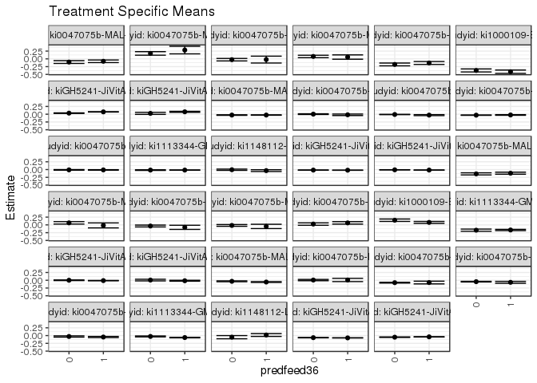

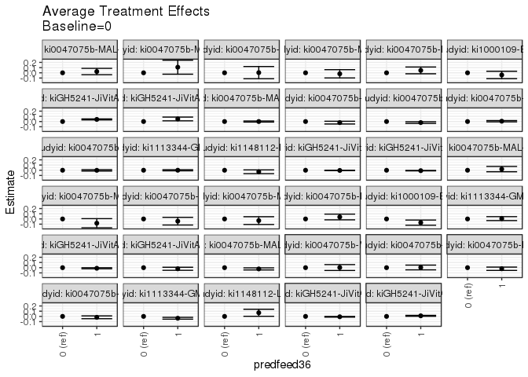

## Results Table

### Parameter: TSM

| agecat | studyid | country | intervention_level | baseline_level | estimate | ci_lower | ci_upper |
| --- | --- | --- | --- | --- | --- | --- | --- |
| 0-3 months | ki0047075b-MAL-ED | BANGLADESH | 0 | NA | -0.1024694 | -0.1475757 | -0.0573631 |
| 0-3 months | ki0047075b-MAL-ED | BANGLADESH | 1 | NA | -0.0778701 | -0.1196576 | -0.0360826 |
| 0-3 months | ki0047075b-MAL-ED | BRAZIL | 0 | NA | 0.1755195 | 0.1186953 | 0.2323437 |
| 0-3 months | ki0047075b-MAL-ED | BRAZIL | 1 | NA | 0.2831542 | 0.1612042 | 0.4051042 |
| 0-3 months | ki0047075b-MAL-ED | INDIA | 0 | NA | -0.0260469 | -0.0663392 | 0.0142454 |
| 0-3 months | ki0047075b-MAL-ED | INDIA | 1 | NA | -0.0225086 | -0.1330506 | 0.0880334 |
| 0-3 months | ki0047075b-MAL-ED | NEPAL | 0 | NA | 0.0775639 | 0.0380542 | 0.1170737 |
| 0-3 months | ki0047075b-MAL-ED | NEPAL | 1 | NA | 0.0584843 | -0.0107188 | 0.1276873 |
| 0-3 months | ki0047075b-MAL-ED | PERU | 0 | NA | -0.1793699 | -0.2244705 | -0.1342693 |
| 0-3 months | ki0047075b-MAL-ED | PERU | 1 | NA | -0.1328246 | -0.1798206 | -0.0858286 |
| 0-3 months | ki1000109-EE | PAKISTAN | 0 | NA | -0.3725009 | -0.4205554 | -0.3244465 |
| 0-3 months | ki1000109-EE | PAKISTAN | 1 | NA | -0.4137773 | -0.4672108 | -0.3603438 |
| 0-3 months | kiGH5241-JiVitA-3 | BANGLADESH | 0 | NA | 0.0345794 | 0.0249645 | 0.0441943 |
| 0-3 months | kiGH5241-JiVitA-3 | BANGLADESH | 1 | NA | 0.0753683 | 0.0694706 | 0.0812660 |
| 0-3 months | kiGH5241-JiVitA-4 | BANGLADESH | 0 | NA | 0.0276971 | -0.0049639 | 0.0603580 |
| 0-3 months | kiGH5241-JiVitA-4 | BANGLADESH | 1 | NA | 0.0772115 | 0.0613932 | 0.0930297 |
| 3-6 months | ki0047075b-MAL-ED | BANGLADESH | 0 | NA | -0.1392356 | -0.1734807 | -0.1049905 |
| 3-6 months | ki0047075b-MAL-ED | BANGLADESH | 1 | NA | -0.1171361 | -0.1496672 | -0.0846050 |
| 3-6 months | ki0047075b-MAL-ED | BRAZIL | 0 | NA | 0.0659951 | 0.0264483 | 0.1055419 |
| 3-6 months | ki0047075b-MAL-ED | BRAZIL | 1 | NA | -0.0159826 | -0.0962865 | 0.0643214 |
| 3-6 months | ki0047075b-MAL-ED | INDIA | 0 | NA | -0.0356176 | -0.0656377 | -0.0055974 |
| 3-6 months | ki0047075b-MAL-ED | INDIA | 1 | NA | -0.0779807 | -0.1447082 | -0.0112532 |
| 3-6 months | ki0047075b-MAL-ED | NEPAL | 0 | NA | -0.0172549 | -0.0460005 | 0.0114908 |
| 3-6 months | ki0047075b-MAL-ED | NEPAL | 1 | NA | -0.0488165 | -0.1176382 | 0.0200052 |
| 3-6 months | ki0047075b-MAL-ED | PERU | 0 | NA | 0.0269629 | -0.0118907 | 0.0658166 |
| 3-6 months | ki0047075b-MAL-ED | PERU | 1 | NA | 0.0647532 | 0.0253600 | 0.1041463 |
| 3-6 months | ki1000109-EE | PAKISTAN | 0 | NA | 0.1508876 | 0.1121831 | 0.1895922 |
| 3-6 months | ki1000109-EE | PAKISTAN | 1 | NA | 0.0803893 | 0.0492834 | 0.1114953 |
| 3-6 months | ki1113344-GMS-Nepal | NEPAL | 0 | NA | -0.1703459 | -0.2055007 | -0.1351910 |
| 3-6 months | ki1113344-GMS-Nepal | NEPAL | 1 | NA | -0.1635852 | -0.1833631 | -0.1438074 |
| 3-6 months | kiGH5241-JiVitA-3 | BANGLADESH | 0 | NA | -0.0003298 | -0.0097233 | 0.0090637 |
| 3-6 months | kiGH5241-JiVitA-3 | BANGLADESH | 1 | NA | -0.0116396 | -0.0173694 | -0.0059098 |
| 3-6 months | kiGH5241-JiVitA-4 | BANGLADESH | 0 | NA | 0.0053361 | -0.0214259 | 0.0320981 |
| 3-6 months | kiGH5241-JiVitA-4 | BANGLADESH | 1 | NA | -0.0159956 | -0.0309397 | -0.0010516 |
| 6-12 months | ki0047075b-MAL-ED | BANGLADESH | 0 | NA | -0.0340441 | -0.0479649 | -0.0201233 |
| 6-12 months | ki0047075b-MAL-ED | BANGLADESH | 1 | NA | -0.0578742 | -0.0709853 | -0.0447632 |
| 6-12 months | ki0047075b-MAL-ED | BRAZIL | 0 | NA | 0.0060922 | -0.0147716 | 0.0269560 |
| 6-12 months | ki0047075b-MAL-ED | BRAZIL | 1 | NA | 0.0087867 | -0.0433425 | 0.0609159 |
| 6-12 months | ki0047075b-MAL-ED | INDIA | 0 | NA | -0.0779819 | -0.0906724 | -0.0652914 |
| 6-12 months | ki0047075b-MAL-ED | INDIA | 1 | NA | -0.0741303 | -0.1177465 | -0.0305140 |
| 6-12 months | ki0047075b-MAL-ED | NEPAL | 0 | NA | -0.0462119 | -0.0574144 | -0.0350094 |
| 6-12 months | ki0047075b-MAL-ED | NEPAL | 1 | NA | -0.0668727 | -0.0969916 | -0.0367538 |
| 6-12 months | ki0047075b-MAL-ED | PERU | 0 | NA | -0.0289592 | -0.0494730 | -0.0084453 |
| 6-12 months | ki0047075b-MAL-ED | PERU | 1 | NA | -0.0464921 | -0.0647475 | -0.0282367 |
| 6-12 months | ki1113344-GMS-Nepal | NEPAL | 0 | NA | -0.0278071 | -0.0430588 | -0.0125555 |
| 6-12 months | ki1113344-GMS-Nepal | NEPAL | 1 | NA | -0.0634247 | -0.0723135 | -0.0545359 |
| 6-12 months | ki1148112-LCNI-5 | MALAWI | 0 | NA | -0.0508592 | -0.1021109 | 0.0003926 |
| 6-12 months | ki1148112-LCNI-5 | MALAWI | 1 | NA | 0.0189801 | -0.0265436 | 0.0645037 |
| 6-12 months | kiGH5241-JiVitA-3 | BANGLADESH | 0 | NA | -0.0667423 | -0.0726113 | -0.0608734 |
| 6-12 months | kiGH5241-JiVitA-3 | BANGLADESH | 1 | NA | -0.0739748 | -0.0771744 | -0.0707752 |
| 6-12 months | kiGH5241-JiVitA-4 | BANGLADESH | 0 | NA | -0.0516107 | -0.0597259 | -0.0434955 |
| 6-12 months | kiGH5241-JiVitA-4 | BANGLADESH | 1 | NA | -0.0405373 | -0.0456600 | -0.0354145 |
| 12-24 months | ki0047075b-MAL-ED | BANGLADESH | 0 | NA | -0.0272870 | -0.0356396 | -0.0189344 |
| 12-24 months | ki0047075b-MAL-ED | BANGLADESH | 1 | NA | -0.0270095 | -0.0334760 | -0.0205430 |
| 12-24 months | ki0047075b-MAL-ED | BRAZIL | 0 | NA | 0.0024849 | -0.0089389 | 0.0139088 |
| 12-24 months | ki0047075b-MAL-ED | BRAZIL | 1 | NA | -0.0183753 | -0.0426367 | 0.0058860 |
| 12-24 months | ki0047075b-MAL-ED | INDIA | 0 | NA | -0.0087541 | -0.0140860 | -0.0034221 |
| 12-24 months | ki0047075b-MAL-ED | INDIA | 1 | NA | -0.0289895 | -0.0449818 | -0.0129973 |
| 12-24 months | ki0047075b-MAL-ED | NEPAL | 0 | NA | -0.0304017 | -0.0358664 | -0.0249370 |
| 12-24 months | ki0047075b-MAL-ED | NEPAL | 1 | NA | -0.0242462 | -0.0353832 | -0.0131091 |
| 12-24 months | ki0047075b-MAL-ED | PERU | 0 | NA | -0.0106140 | -0.0209237 | -0.0003042 |
| 12-24 months | ki0047075b-MAL-ED | PERU | 1 | NA | -0.0118356 | -0.0204902 | -0.0031810 |
| 12-24 months | ki1113344-GMS-Nepal | NEPAL | 0 | NA | -0.0173261 | -0.0265860 | -0.0080663 |
| 12-24 months | ki1113344-GMS-Nepal | NEPAL | 1 | NA | -0.0171642 | -0.0226911 | -0.0116373 |
| 12-24 months | ki1148112-LCNI-5 | MALAWI | 0 | NA | -0.0053185 | -0.0263716 | 0.0157345 |
| 12-24 months | ki1148112-LCNI-5 | MALAWI | 1 | NA | -0.0345407 | -0.0639658 | -0.0051157 |
| 12-24 months | kiGH5241-JiVitA-3 | BANGLADESH | 0 | NA | -0.0175287 | -0.0212862 | -0.0137712 |
| 12-24 months | kiGH5241-JiVitA-3 | BANGLADESH | 1 | NA | -0.0210019 | -0.0231513 | -0.0188525 |
| 12-24 months | kiGH5241-JiVitA-4 | BANGLADESH | 0 | NA | -0.0087902 | -0.0120821 | -0.0054982 |
| 12-24 months | kiGH5241-JiVitA-4 | BANGLADESH | 1 | NA | -0.0166967 | -0.0188861 | -0.0145073 |

### Parameter: E(Y)

| agecat | studyid | country | intervention_level | baseline_level | estimate | ci_lower | ci_upper |
| --- | --- | --- | --- | --- | --- | --- | --- |
| 0-3 months | ki0047075b-MAL-ED | BANGLADESH | NA | NA | -0.0342392 | -0.0665521 | -0.0019264 |
| 0-3 months | ki0047075b-MAL-ED | BRAZIL | NA | NA | 0.1928587 | 0.1409027 | 0.2448147 |
| 0-3 months | ki0047075b-MAL-ED | INDIA | NA | NA | -0.0254448 | -0.0636028 | 0.0127132 |
| 0-3 months | ki0047075b-MAL-ED | NEPAL | NA | NA | 0.0746202 | 0.0395269 | 0.1097135 |
| 0-3 months | ki0047075b-MAL-ED | PERU | NA | NA | -0.1586062 | -0.1913606 | -0.1258518 |
| 0-3 months | ki1000109-EE | PAKISTAN | NA | NA | -0.3938516 | -0.4364614 | -0.3512419 |
| 0-3 months | kiGH5241-JiVitA-3 | BANGLADESH | NA | NA | 0.0651938 | 0.0595783 | 0.0708094 |
| 0-3 months | kiGH5241-JiVitA-4 | BANGLADESH | NA | NA | 0.0642202 | 0.0489852 | 0.0794552 |
| 3-6 months | ki0047075b-MAL-ED | BANGLADESH | NA | NA | -0.0212379 | -0.0443179 | 0.0018421 |
| 3-6 months | ki0047075b-MAL-ED | BRAZIL | NA | NA | 0.0604904 | 0.0239698 | 0.0970111 |
| 3-6 months | ki0047075b-MAL-ED | INDIA | NA | NA | -0.0401251 | -0.0685271 | -0.0117231 |
| 3-6 months | ki0047075b-MAL-ED | NEPAL | NA | NA | -0.0214542 | -0.0480456 | 0.0051373 |
| 3-6 months | ki0047075b-MAL-ED | PERU | NA | NA | 0.0280549 | -0.0030513 | 0.0591612 |
| 3-6 months | ki1000109-EE | PAKISTAN | NA | NA | 0.0701161 | 0.0419135 | 0.0983187 |
| 3-6 months | ki1113344-GMS-Nepal | NEPAL | NA | NA | -0.1671388 | -0.1860153 | -0.1482623 |
| 3-6 months | kiGH5241-JiVitA-3 | BANGLADESH | NA | NA | -0.0050971 | -0.0104963 | 0.0003021 |
| 3-6 months | kiGH5241-JiVitA-4 | BANGLADESH | NA | NA | -0.0093314 | -0.0232659 | 0.0046030 |
| 6-12 months | ki0047075b-MAL-ED | BANGLADESH | NA | NA | -0.0808013 | -0.0912137 | -0.0703889 |
| 6-12 months | ki0047075b-MAL-ED | BRAZIL | NA | NA | 0.0065644 | -0.0129183 | 0.0260472 |
| 6-12 months | ki0047075b-MAL-ED | INDIA | NA | NA | -0.0776724 | -0.0898619 | -0.0654829 |
| 6-12 months | ki0047075b-MAL-ED | NEPAL | NA | NA | -0.0488126 | -0.0594641 | -0.0381610 |
| 6-12 months | ki0047075b-MAL-ED | PERU | NA | NA | -0.0373127 | -0.0513600 | -0.0232653 |
| 6-12 months | ki1113344-GMS-Nepal | NEPAL | NA | NA | -0.0626340 | -0.0709302 | -0.0543379 |
| 6-12 months | ki1148112-LCNI-5 | MALAWI | NA | NA | -0.0281085 | -0.0675243 | 0.0113073 |
| 6-12 months | kiGH5241-JiVitA-3 | BANGLADESH | NA | NA | -0.0720156 | -0.0751021 | -0.0689290 |
| 6-12 months | kiGH5241-JiVitA-4 | BANGLADESH | NA | NA | -0.0387210 | -0.0435056 | -0.0339363 |
| 12-24 months | ki0047075b-MAL-ED | BANGLADESH | NA | NA | -0.0177078 | -0.0231267 | -0.0122889 |
| 12-24 months | ki0047075b-MAL-ED | BRAZIL | NA | NA | -0.0013016 | -0.0119070 | 0.0093038 |
| 12-24 months | ki0047075b-MAL-ED | INDIA | NA | NA | -0.0098833 | -0.0150187 | -0.0047479 |
| 12-24 months | ki0047075b-MAL-ED | NEPAL | NA | NA | -0.0295113 | -0.0345712 | -0.0244514 |
| 12-24 months | ki0047075b-MAL-ED | PERU | NA | NA | -0.0092560 | -0.0162726 | -0.0022393 |
| 12-24 months | ki1113344-GMS-Nepal | NEPAL | NA | NA | -0.0170788 | -0.0222320 | -0.0119257 |
| 12-24 months | ki1148112-LCNI-5 | MALAWI | NA | NA | -0.0140852 | -0.0319419 | 0.0037715 |
| 12-24 months | kiGH5241-JiVitA-3 | BANGLADESH | NA | NA | -0.0193591 | -0.0213957 | -0.0173226 |
| 12-24 months | kiGH5241-JiVitA-4 | BANGLADESH | NA | NA | -0.0147196 | -0.0167684 | -0.0126707 |

### Parameter: ATE

| agecat | studyid | country | intervention_level | baseline_level | estimate | ci_lower | ci_upper |
| --- | --- | --- | --- | --- | --- | --- | --- |
| 0-3 months | ki0047075b-MAL-ED | BANGLADESH | 0 | 0 | 0.0000000 | 0.0000000 | 0.0000000 |
| 0-3 months | ki0047075b-MAL-ED | BANGLADESH | 1 | 0 | 0.0245993 | -0.0364421 | 0.0856406 |
| 0-3 months | ki0047075b-MAL-ED | BRAZIL | 0 | 0 | 0.0000000 | 0.0000000 | 0.0000000 |
| 0-3 months | ki0047075b-MAL-ED | BRAZIL | 1 | 0 | 0.1076347 | -0.0266811 | 0.2419504 |
| 0-3 months | ki0047075b-MAL-ED | INDIA | 0 | 0 | 0.0000000 | 0.0000000 | 0.0000000 |
| 0-3 months | ki0047075b-MAL-ED | INDIA | 1 | 0 | 0.0035383 | -0.1139509 | 0.1210276 |
| 0-3 months | ki0047075b-MAL-ED | NEPAL | 0 | 0 | 0.0000000 | 0.0000000 | 0.0000000 |
| 0-3 months | ki0047075b-MAL-ED | NEPAL | 1 | 0 | -0.0190797 | -0.0987671 | 0.0606077 |
| 0-3 months | ki0047075b-MAL-ED | PERU | 0 | 0 | 0.0000000 | 0.0000000 | 0.0000000 |
| 0-3 months | ki0047075b-MAL-ED | PERU | 1 | 0 | 0.0465453 | -0.0185447 | 0.1116354 |
| 0-3 months | ki1000109-EE | PAKISTAN | 0 | 0 | 0.0000000 | 0.0000000 | 0.0000000 |
| 0-3 months | ki1000109-EE | PAKISTAN | 1 | 0 | -0.0412764 | -0.1122180 | 0.0296652 |
| 0-3 months | kiGH5241-JiVitA-3 | BANGLADESH | 0 | 0 | 0.0000000 | 0.0000000 | 0.0000000 |
| 0-3 months | kiGH5241-JiVitA-3 | BANGLADESH | 1 | 0 | 0.0407889 | 0.0305680 | 0.0510098 |
| 0-3 months | kiGH5241-JiVitA-4 | BANGLADESH | 0 | 0 | 0.0000000 | 0.0000000 | 0.0000000 |
| 0-3 months | kiGH5241-JiVitA-4 | BANGLADESH | 1 | 0 | 0.0495144 | 0.0135932 | 0.0854355 |
| 3-6 months | ki0047075b-MAL-ED | BANGLADESH | 0 | 0 | 0.0000000 | 0.0000000 | 0.0000000 |
| 3-6 months | ki0047075b-MAL-ED | BANGLADESH | 1 | 0 | 0.0220995 | -0.0289252 | 0.0731242 |
| 3-6 months | ki0047075b-MAL-ED | BRAZIL | 0 | 0 | 0.0000000 | 0.0000000 | 0.0000000 |
| 3-6 months | ki0047075b-MAL-ED | BRAZIL | 1 | 0 | -0.0819777 | -0.1700788 | 0.0061235 |
| 3-6 months | ki0047075b-MAL-ED | INDIA | 0 | 0 | 0.0000000 | 0.0000000 | 0.0000000 |
| 3-6 months | ki0047075b-MAL-ED | INDIA | 1 | 0 | -0.0423631 | -0.1162986 | 0.0315724 |
| 3-6 months | ki0047075b-MAL-ED | NEPAL | 0 | 0 | 0.0000000 | 0.0000000 | 0.0000000 |
| 3-6 months | ki0047075b-MAL-ED | NEPAL | 1 | 0 | -0.0315617 | -0.1061291 | 0.0430058 |
| 3-6 months | ki0047075b-MAL-ED | PERU | 0 | 0 | 0.0000000 | 0.0000000 | 0.0000000 |
| 3-6 months | ki0047075b-MAL-ED | PERU | 1 | 0 | 0.0377902 | -0.0170467 | 0.0926272 |
| 3-6 months | ki1000109-EE | PAKISTAN | 0 | 0 | 0.0000000 | 0.0000000 | 0.0000000 |
| 3-6 months | ki1000109-EE | PAKISTAN | 1 | 0 | -0.0704983 | -0.1204436 | -0.0205530 |
| 3-6 months | ki1113344-GMS-Nepal | NEPAL | 0 | 0 | 0.0000000 | 0.0000000 | 0.0000000 |
| 3-6 months | ki1113344-GMS-Nepal | NEPAL | 1 | 0 | 0.0067606 | -0.0310155 | 0.0445368 |
| 3-6 months | kiGH5241-JiVitA-3 | BANGLADESH | 0 | 0 | 0.0000000 | 0.0000000 | 0.0000000 |
| 3-6 months | kiGH5241-JiVitA-3 | BANGLADESH | 1 | 0 | -0.0113097 | -0.0217122 | -0.0009073 |
| 3-6 months | kiGH5241-JiVitA-4 | BANGLADESH | 0 | 0 | 0.0000000 | 0.0000000 | 0.0000000 |
| 3-6 months | kiGH5241-JiVitA-4 | BANGLADESH | 1 | 0 | -0.0213317 | -0.0507851 | 0.0081216 |
| 6-12 months | ki0047075b-MAL-ED | BANGLADESH | 0 | 0 | 0.0000000 | 0.0000000 | 0.0000000 |
| 6-12 months | ki0047075b-MAL-ED | BANGLADESH | 1 | 0 | -0.0238301 | -0.0436309 | -0.0040294 |
| 6-12 months | ki0047075b-MAL-ED | BRAZIL | 0 | 0 | 0.0000000 | 0.0000000 | 0.0000000 |
| 6-12 months | ki0047075b-MAL-ED | BRAZIL | 1 | 0 | 0.0026945 | -0.0534549 | 0.0588439 |
| 6-12 months | ki0047075b-MAL-ED | INDIA | 0 | 0 | 0.0000000 | 0.0000000 | 0.0000000 |
| 6-12 months | ki0047075b-MAL-ED | INDIA | 1 | 0 | 0.0038517 | -0.0415621 | 0.0492654 |
| 6-12 months | ki0047075b-MAL-ED | NEPAL | 0 | 0 | 0.0000000 | 0.0000000 | 0.0000000 |
| 6-12 months | ki0047075b-MAL-ED | NEPAL | 1 | 0 | -0.0206608 | -0.0524655 | 0.0111439 |
| 6-12 months | ki0047075b-MAL-ED | PERU | 0 | 0 | 0.0000000 | 0.0000000 | 0.0000000 |
| 6-12 months | ki0047075b-MAL-ED | PERU | 1 | 0 | -0.0175330 | -0.0445951 | 0.0095292 |
| 6-12 months | ki1113344-GMS-Nepal | NEPAL | 0 | 0 | 0.0000000 | 0.0000000 | 0.0000000 |
| 6-12 months | ki1113344-GMS-Nepal | NEPAL | 1 | 0 | -0.0356176 | -0.0532096 | -0.0180255 |
| 6-12 months | ki1148112-LCNI-5 | MALAWI | 0 | 0 | 0.0000000 | 0.0000000 | 0.0000000 |
| 6-12 months | ki1148112-LCNI-5 | MALAWI | 1 | 0 | 0.0698392 | 0.0021777 | 0.1375007 |
| 6-12 months | kiGH5241-JiVitA-3 | BANGLADESH | 0 | 0 | 0.0000000 | 0.0000000 | 0.0000000 |
| 6-12 months | kiGH5241-JiVitA-3 | BANGLADESH | 1 | 0 | -0.0072325 | -0.0134936 | -0.0009713 |
| 6-12 months | kiGH5241-JiVitA-4 | BANGLADESH | 0 | 0 | 0.0000000 | 0.0000000 | 0.0000000 |
| 6-12 months | kiGH5241-JiVitA-4 | BANGLADESH | 1 | 0 | 0.0110734 | 0.0018514 | 0.0202954 |
| 12-24 months | ki0047075b-MAL-ED | BANGLADESH | 0 | 0 | 0.0000000 | 0.0000000 | 0.0000000 |
| 12-24 months | ki0047075b-MAL-ED | BANGLADESH | 1 | 0 | 0.0002775 | -0.0100331 | 0.0105881 |
| 12-24 months | ki0047075b-MAL-ED | BRAZIL | 0 | 0 | 0.0000000 | 0.0000000 | 0.0000000 |
| 12-24 months | ki0047075b-MAL-ED | BRAZIL | 1 | 0 | -0.0208603 | -0.0472064 | 0.0054859 |
| 12-24 months | ki0047075b-MAL-ED | INDIA | 0 | 0 | 0.0000000 | 0.0000000 | 0.0000000 |
| 12-24 months | ki0047075b-MAL-ED | INDIA | 1 | 0 | -0.0202355 | -0.0371093 | -0.0033616 |
| 12-24 months | ki0047075b-MAL-ED | NEPAL | 0 | 0 | 0.0000000 | 0.0000000 | 0.0000000 |
| 12-24 months | ki0047075b-MAL-ED | NEPAL | 1 | 0 | 0.0061556 | -0.0060556 | 0.0183667 |
| 12-24 months | ki0047075b-MAL-ED | PERU | 0 | 0 | 0.0000000 | 0.0000000 | 0.0000000 |
| 12-24 months | ki0047075b-MAL-ED | PERU | 1 | 0 | -0.0012216 | -0.0145806 | 0.0121374 |
| 12-24 months | ki1113344-GMS-Nepal | NEPAL | 0 | 0 | 0.0000000 | 0.0000000 | 0.0000000 |
| 12-24 months | ki1113344-GMS-Nepal | NEPAL | 1 | 0 | 0.0001619 | -0.0105831 | 0.0109070 |
| 12-24 months | ki1148112-LCNI-5 | MALAWI | 0 | 0 | 0.0000000 | 0.0000000 | 0.0000000 |
| 12-24 months | ki1148112-LCNI-5 | MALAWI | 1 | 0 | -0.0292222 | -0.0654032 | 0.0069588 |
| 12-24 months | kiGH5241-JiVitA-3 | BANGLADESH | 0 | 0 | 0.0000000 | 0.0000000 | 0.0000000 |
| 12-24 months | kiGH5241-JiVitA-3 | BANGLADESH | 1 | 0 | -0.0034732 | -0.0076074 | 0.0006610 |
| 12-24 months | kiGH5241-JiVitA-4 | BANGLADESH | 0 | 0 | 0.0000000 | 0.0000000 | 0.0000000 |
| 12-24 months | kiGH5241-JiVitA-4 | BANGLADESH | 1 | 0 | -0.0079066 | -0.0116519 | -0.0041613 |